# Proyección de Inflación en Bolivia

Modelo ARIMA — Metodología de Box-Jenkins

Análisis Econométrico

07 de julio de 2026

# 1 Comportamiento de las Variables

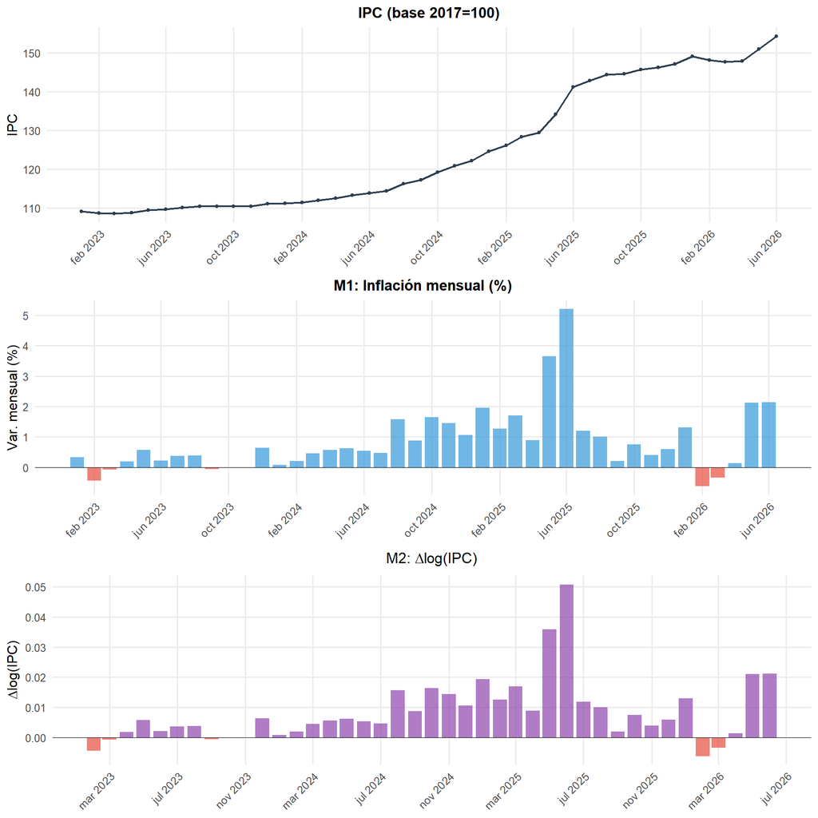

## 1.1 Base de datos consolidada

Base mensual consolidada

| Fecha | IPC | log(IPC) | Δlog(IPC)*100 | Inf.mens.(%) | Inf.ia.(%) | TC Pref. | TC Oficial |
| --- | --- | --- | --- | --- | --- | --- | --- |
| ene 2023 | 109.18 | 4.6930 | NA | 0.330 | 3.14 | 6.92 | 6.96 |
| feb 2023 | 108.70 | 4.6886 | -0.440 | -0.439 | 2.57 | 6.94 | 6.96 |
| mar 2023 | 108.61 | 4.6878 | -0.077 | -0.077 | 2.53 | 7.03 | 6.96 |
| abr 2023 | 108.81 | 4.6896 | 0.184 | 0.184 | 2.70 | 7.06 | 6.96 |
| may 2023 | 109.44 | 4.6954 | 0.573 | 0.574 | 2.90 | 7.10 | 6.96 |
| jun 2023 | 109.68 | 4.6976 | 0.218 | 0.218 | 2.73 | 7.08 | 6.96 |
| jul 2023 | 110.08 | 4.7012 | 0.367 | 0.368 | 2.70 | 7.09 | 6.96 |
| ago 2023 | 110.51 | 4.7051 | 0.385 | 0.386 | 3.06 | 7.08 | 6.96 |
| sept 2023 | 110.44 | 4.7045 | -0.060 | -0.060 | 2.85 | 7.10 | 6.96 |
| oct 2023 | 110.43 | 4.7044 | -0.010 | -0.010 | 2.08 | 7.13 | 6.96 |
| nov 2023 | 110.43 | 4.7043 | -0.003 | -0.003 | 1.59 | 7.15 | 6.96 |
| dic 2023 | 111.12 | 4.7106 | 0.630 | 0.632 | 2.12 | 7.18 | 6.96 |
| ene 2024 | 111.21 | 4.7114 | 0.079 | 0.079 | 1.86 | 7.27 | 6.96 |
| feb 2024 | 111.43 | 4.7134 | 0.200 | 0.200 | 2.52 | 7.45 | 6.96 |
| mar 2024 | 111.94 | 4.7180 | 0.455 | 0.456 | 3.06 | 7.34 | 6.96 |
| abr 2024 | 112.58 | 4.7237 | 0.568 | 0.570 | 3.46 | 7.64 | 6.96 |
| may 2024 | 113.29 | 4.7299 | 0.628 | 0.630 | 3.52 | 7.72 | 6.96 |
| jun 2024 | 113.90 | 4.7353 | 0.534 | 0.535 | 3.84 | 7.82 | 6.96 |
| jul 2024 | 114.43 | 4.7400 | 0.472 | 0.473 | 3.95 | 8.06 | 6.96 |
| ago 2024 | 116.25 | 4.7557 | 1.570 | 1.583 | 5.19 | 8.30 | 6.96 |
| sept 2024 | 117.27 | 4.7645 | 0.876 | 0.880 | 6.18 | 9.02 | 6.96 |
| oct 2024 | 119.20 | 4.7808 | 1.631 | 1.645 | 7.94 | 8.93 | 6.96 |
| nov 2024 | 120.92 | 4.7952 | 1.438 | 1.448 | 9.51 | 9.34 | 6.96 |
| dic 2024 | 122.21 | 4.8057 | 1.056 | 1.062 | 9.97 | 9.61 | 6.96 |
| ene 2025 | 124.59 | 4.8251 | 1.935 | 1.954 | 12.03 | 9.48 | 6.96 |
| feb 2025 | 126.17 | 4.8376 | 1.255 | 1.263 | 13.22 | 10.20 | 6.96 |
| mar 2025 | 128.32 | 4.8546 | 1.693 | 1.708 | 14.63 | 10.82 | 6.96 |
| abr 2025 | 129.47 | 4.8635 | 0.892 | 0.896 | 15.01 | 12.32 | 6.96 |
| may 2025 | 134.20 | 4.8993 | 3.585 | 3.650 | 18.46 | 13.93 | 6.96 |
| jun 2025 | 141.19 | 4.9501 | 5.076 | 5.207 | 23.96 | 14.25 | 6.96 |
| jul 2025 | 142.88 | 4.9620 | 1.192 | 1.199 | 24.86 | 11.78 | 6.96 |
| ago 2025 | 144.32 | 4.9720 | 1.002 | 1.007 | 24.15 | 11.21 | 6.96 |
| sept 2025 | 144.61 | 4.9740 | 0.201 | 0.202 | 23.32 | 11.18 | 6.96 |
| oct 2025 | 145.70 | 4.9815 | 0.749 | 0.752 | 22.23 | 11.91 | 6.96 |
| nov 2025 | 146.27 | 4.9855 | 0.395 | 0.396 | 20.96 | 10.70 | 6.96 |
| dic 2025 | 147.14 | 4.9914 | 0.588 | 0.590 | 20.40 | 8.81 | 6.96 |
| ene 2026 | 149.06 | 5.0044 | 1.300 | 1.308 | 19.64 | 9.03 | 6.96 |
| feb 2026 | 148.14 | 4.9981 | -0.622 | -0.620 | 17.41 | 8.96 | 6.96 |
| mar 2026 | 147.63 | 4.9947 | -0.340 | -0.339 | 15.05 | 9.03 | 6.96 |
| abr 2026 | 147.84 | 4.9961 | 0.136 | 0.136 | 14.18 | 9.41 | 6.96 |
| may 2026 | 150.98 | 5.0172 | 2.108 | 2.130 | 12.51 | 10.17 | 6.96 |
| jun 2026 | 154.22 | 5.0384 | 2.121 | 2.143 | 9.23 | 9.99 | 6.96 |

# 2 Identificación y Estacionariedad

Pruebas de raíz unitaria — con hipótesis nulas

| Prueba | H₀ | Criterio de rechazo | Serie | Estadístico | p-valor | Conclusión |
| --- | --- | --- | --- | --- | --- | --- |
| **M1: Inflación mensual** |  |  |  |  |  |  |
| ADF | Raíz unitaria (no estacionaria) | p < 0.05 → Estacionaria | Inf. mensual (M1) | -2.3095 | 0.4516 | No estac. |
| Phillips-Perron | Raíz unitaria (no estacionaria) | p < 0.05 → Estacionaria | Inf. mensual (M1) | -21.0190 | 0.0300 | Estac. |
| KPSS | Serie estacionaria | p < 0.05 → No estacionaria | Inf. mensual (M1) | 0.4014 | 0.0766 | Estac. |
| **M2: log(IPC)** |  |  |  |  |  |  |
| ADF | Raíz unitaria (no estacionaria) | p < 0.05 → Estacionaria | log(IPC) (M2) | -1.9622 | 0.5885 | No estac. |
| Phillips-Perron | Raíz unitaria (no estacionaria) | p < 0.05 → Estacionaria | log(IPC) (M2) | -4.5192 | 0.8478 | No estac. |
| KPSS | Serie estacionaria | p < 0.05 → No estacionaria | log(IPC) (M2) | 1.0844 | 0.0100 | No estac. |
| **Δlog(IPC)** |  |  |  |  |  |  |
| ADF | Raíz unitaria (no estacionaria) | p < 0.05 → Estacionaria | Δlog(IPC) | -2.2554 | 0.4731 | No estac. |
| Phillips-Perron | Raíz unitaria (no estacionaria) | p < 0.05 → Estacionaria | Δlog(IPC) | -20.2576 | 0.0371 | Estac. |
| KPSS | Serie estacionaria | p < 0.05 → No estacionaria | Δlog(IPC) | 0.3903 | 0.0813 | Estac. |

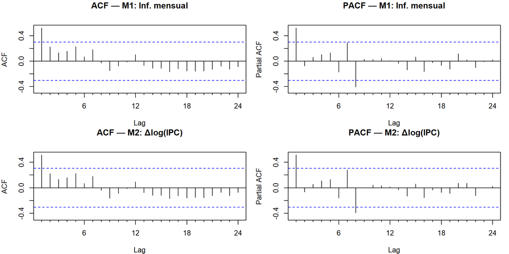

# 3 Estimación y Selección — Dos Métodos

El scoring compuesto integra: **RMSE** + **MAPE** + promedio(**AICc**, **BIC**, **Hannan-Quinn**) + 0.3 × Complejidad + penalizaciones por Ljung-Box y raíces inversas.

## 3.1 M1: Método Directo (inflación mensual %)

M1 Directo — Top 15 de 49 modelos (variable: inflación mensual %)

| Modelo | d | AICc | BIC | HQ | RMSE | MAPE | LB12(p) | Raices | Score |
| --- | --- | --- | --- | --- | --- | --- | --- | --- | --- |
| ARIMA(2,1,4) | 1 | 116.67 | 125.27 | 117.64 | 0.7667 | 135.640 | 0.6001 | OK | -3.610 |
| ARIMA(3,1,4) | 1 | 119.62 | 128.83 | 120.11 | 0.7499 | 125.928 | 0.4533 | OK | -2.823 |
| ARIMA(1,1,1) | 1 | 116.69 | 121.18 | 117.91 | 0.9050 | 157.981 | 0.1416 | OK | -2.149 |
| ARIMA(2,0,3) | 0 | 116.88 | 125.75 | 118.04 | 0.7530 | 428.207 | 0.5960 | OK | -2.024 |
| ARIMA(2,1,2) | 1 | 118.55 | 125.40 | 119.95 | 0.8523 | 147.379 | 0.1201 | OK | -1.928 |
| ARIMA(0,1,2) | 1 | 116.85 | 121.35 | 118.08 | 0.9087 | 216.880 | 0.0882 | OK | -1.664 |
| ARIMA(4,1,1) | 1 | 118.56 | 126.37 | 119.84 | 0.8350 | 211.857 | 0.2496 | OK | -1.582 |
| ARIMA(4,1,4) | 1 | 122.80 | 132.41 | 122.61 | 0.7610 | 126.277 | 0.3739 | OK | -1.491 |
| ARIMA(4,1,2) | 1 | 119.48 | 128.09 | 120.46 | 0.8104 | 237.042 | 0.3328 | OK | -1.336 |
| ARIMA(1,1,4) | 1 | 120.47 | 128.28 | 121.74 | 0.8423 | 136.791 | 0.1074 | OK | -1.306 |
| ARIMA(0,1,3) | 1 | 118.79 | 124.53 | 120.17 | 0.9012 | 155.646 | 0.0959 | OK | -1.255 |
| ARIMA(1,1,2) | 1 | 118.92 | 124.66 | 120.30 | 0.9028 | 176.540 | 0.0759 | OK | -1.054 |
| ARIMA(2,1,1) | 1 | 118.90 | 124.64 | 120.28 | 0.9029 | 177.665 | 0.0785 | OK | -1.052 |
| ARIMA(2,1,3) | 1 | 121.31 | 129.12 | 122.58 | 0.8334 | 171.336 | 0.1924 | OK | -0.952 |
| ARIMA(3,0,3) | 0 | 119.89 | 129.43 | 120.63 | 0.7600 | 412.716 | 0.4897 | OK | -0.860 |

> M1 elegiría **ARIMA(2,1,4)** por score propio, pero se fuerza a **ARIMA(1,0,0)** (mismo AR/MA que M2, con d=0 porque la inflación mensual ya es una primera diferencia del IPC).

## 3.2 M2: Método Logarítmico (log IPC)

M2 Logarítmico — Top 15 de 48 modelos (variable: log IPC)

| Modelo | d | AICc | BIC | HQ | RMSE | MAPE | LB12(p) | Raices | Score |
| --- | --- | --- | --- | --- | --- | --- | --- | --- | --- |
| ARIMA(1,1,0) | 1 | -261.96 | -258.85 | -261.03 | 0.00924 | 0.122 | 0.0599 | OK | -1.598 |
| ARIMA(1,1,1) | 1 | -259.88 | -255.39 | -258.66 | 0.00921 | 0.121 | 0.0641 | OK | -1.370 |
| ARIMA(2,1,0) | 1 | -259.77 | -255.28 | -258.55 | 0.00922 | 0.120 | 0.0556 | OK | -1.369 |
| ARIMA(0,1,2) | 1 | -256.37 | -251.88 | -255.15 | 0.00960 | 0.133 | 0.0603 | OK | -1.145 |
| ARIMA(2,1,2) | 1 | -259.15 | -252.29 | -257.74 | 0.00865 | 0.121 | 0.0754 | OK | -1.077 |
| ARIMA(0,1,3) | 1 | -256.31 | -250.57 | -254.92 | 0.00928 | 0.128 | 0.0657 | OK | -1.040 |
| ARIMA(3,1,1) | 1 | -258.06 | -251.21 | -256.66 | 0.00876 | 0.122 | 0.0583 | OK | -1.022 |
| ARIMA(3,1,2) | 1 | -257.45 | -249.64 | -256.18 | 0.00846 | 0.116 | 0.0623 | OK | -0.911 |
| ARIMA(2,1,3) | 1 | -257.07 | -249.26 | -255.80 | 0.00855 | 0.118 | 0.0511 | OK | -0.879 |
| ARIMA(3,1,4) | 1 | -259.33 | -250.13 | -258.84 | 0.00754 | 0.104 | 0.3692 | OK | -0.827 |
| ARIMA(1,1,4) | 1 | -255.62 | -247.80 | -254.34 | 0.00873 | 0.117 | 0.0664 | OK | -0.816 |
| ARIMA(0,1,4) | 1 | -252.88 | -246.02 | -251.47 | 0.00929 | 0.129 | 0.1598 | OK | -0.757 |
| ARIMA(2,1,4) | 1 | -255.34 | -246.74 | -254.36 | 0.00832 | 0.113 | 0.0500 | OK | -0.714 |
| ARIMA(4,1,2) | 1 | -253.40 | -244.80 | -252.42 | 0.00841 | 0.109 | 0.0525 | OK | -0.666 |
| ARIMA(4,1,3) | 1 | -255.82 | -246.62 | -255.33 | 0.00772 | 0.110 | 0.0568 | OK | -0.660 |

## 3.3 Comparación (M1: ARIMA(1,0,0) vs M2: ARIMA(1,1,0))

M1: ARIMA(1,0,0) sobre inf. mensual vs M2: ARIMA(1,1,0) sobre log(IPC)

| Criterio | M1: Directo | M2: Logarítmico |
| --- | --- | --- |
| Especificación forzada | ARIMA(1,0,0) | ARIMA(1,1,0) |
| AIC | 115.88 | -262.28 |
| BIC | 121.09 | -258.85 |
| AICc | 116.51 | -261.96 |
| Hannan-Quinn | 117.79 | -261.03 |
| RMSE (train) | 0.891446 | 0.009239 |
| MAPE (train) | 487.3698 | 0.122 |
| Ljung-Box h=12 (p) | 0.1873 | 0.0599 |

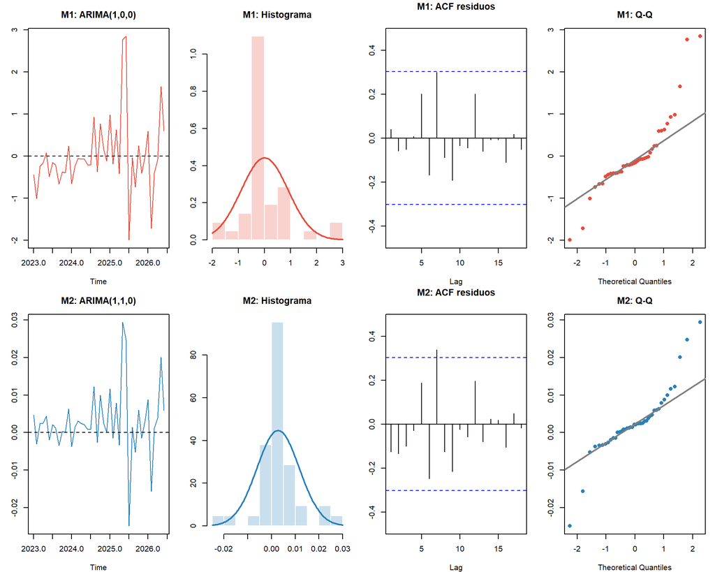

# 4 Backtesting

Se reservan los últimos 6 meses. M1 usa **ARIMA(1,0,0)** y M2 usa **ARIMA(1,1,0)**. Se comparan en **inflación mensual**.

Backtesting — Inflación mensual observada vs. pronosticada

| Fecha | Obs. (%) | M1 pron. (%) | M1 error | M2 pron. (%) | M2 error |
| --- | --- | --- | --- | --- | --- |
| ene 2026 | 1.3081 | 0.6931 | -0.6150 | 0.4303 | -0.8778 |
| feb 2026 | -0.6197 | 0.7504 | 1.3701 | 0.3141 | 0.9338 |
| mar 2026 | -0.3393 | 0.7822 | 1.1216 | 0.2293 | 0.5686 |
| abr 2026 | 0.1357 | 0.7999 | 0.6641 | 0.1674 | 0.0317 |
| may 2026 | 2.1301 | 0.8096 | -1.3205 | 0.1222 | -2.0079 |
| jun 2026 | 2.1432 | 0.8151 | -1.3281 | 0.0892 | -2.0540 |

Métricas de backtesting — inflación mensual

| Métrica | M1: Directo | M2: Logarítmico |
| --- | --- | --- |
| RMSE (pp) | 1.1152 | 1.3049 |
| MAE (pp) | 1.0699 | 1.0790 |

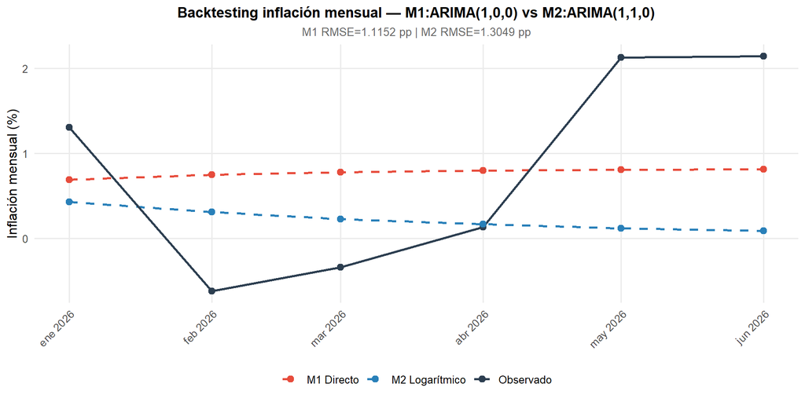

# 5 Pronóstico Final

## 5.1 Proyección comparada — Inflación

Proyección de inflación — M1: ARIMA(1,0,0) vs M2: ARIMA(1,1,0)

| Mes | M1 mensual (%) | M1 interanual (%) | M2 mensual (%) | M2 interanual (%) |
| --- | --- | --- | --- | --- |
| Julio | 1.5492 | 9.61 | 1.5507 | 9.61 |
| Agosto | 1.2302 | 9.85 | 1.1229 | 9.74 |
| Septiembre | 1.0588 | 10.79 | 0.8136 | 10.41 |
| Octubre | 0.9668 | 11.03 | 0.5898 | 10.23 |
| Noviembre | 0.9173 | 11.60 | 0.4276 | 10.26 |
| Diciembre | 0.8908 | 11.94 | 0.3101 | 9.96 |
| Enero | 0.8765 | 11.46 | 0.2250 | 8.78 |

## 5.2 Inflación interanual — M1 vs M2

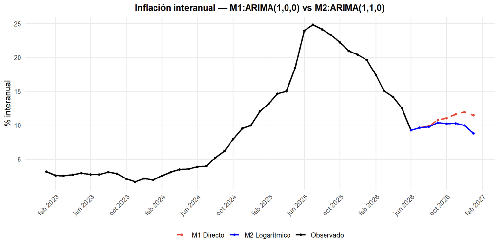

# 6 Escenario Contrafactual vs. Post-Bloqueos

La proyección ARIMA (M2) captura la dinámica tendencial de la inflación **sin disrupciones**. Se compara contra el escenario que incorpora el efecto de los bloqueos de mayo 2025.

Contrafactual ARIMA (M2) vs. escenario post-bloqueos — Inflación interanual

| Mes | M2 mensual (%) | M2 interanual (%) — Contrafactual | Interanual (%) — Post-bloqueos | Diferencia (pp) |
| --- | --- | --- | --- | --- |
| Julio | 1.5507 | 9.61 | 10.12 | 0.51 |
| Agosto | 1.1229 | 9.74 | 10.54 | 0.81 |
| Septiembre | 0.8136 | 10.41 | 11.61 | 1.20 |
| Octubre | 0.5898 | 10.23 | 12.25 | 2.02 |
| Noviembre | 0.4276 | 10.26 | 13.05 | 2.79 |
| Diciembre | 0.3101 | 9.96 | 13.62 | 3.66 |

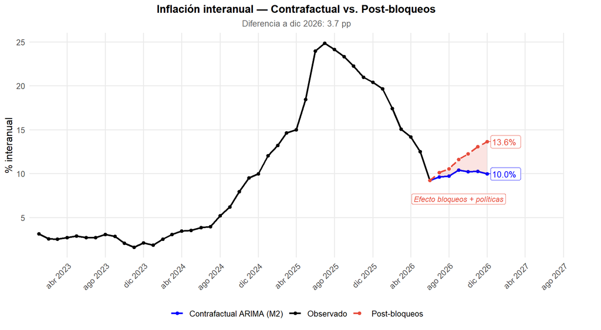

> A diciembre 2026, el escenario post-bloqueos proyecta una inflación interanual de **13.6%**, mientras que el contrafactual ARIMA (M2) estima **10%** — una diferencia de **3.7 puntos porcentuales** atribuible al efecto de los bloqueos de mayo 2025.

*Scoring compuesto: RMSE + MAPE + (AICc + BIC + HQ)/3 + 0.3·Complejidad + penalizaciones LB y raíces.* *M1: ARIMA(1,0,0) sobre inf. mensual (d=0) | M2: ARIMA(1,1,0) sobre log(IPC) (d=1). Mismo AR/MA, diferenciación equivalente.*